# Tipologia i cicle de vida de les dades: Pràctica 2

Diana Campillo Campbell

27 de desembre de 2018

# 1 Descripció del dataset. Perquè és important i quina pregunta/problema pretén respondre?

En l’actualitat, malauradament, és comú en la comunitat científica la migració de persones per a poder-se desenvolupar professionalment. Molts països no tenen la cultura d’acollir aquest potencial que tenen i qui vol dedicar-se a la recerca sovint es veu amb la necessitat de marxar per poder continuar la seva carrera professional. Espanya és un clar exemple. Però ara tenim la oportunitat de comprovar-ho i poder veure quant de cert és aquesta afirmació.

Centrarem el nostre estudi a Espanya i EEUU. Les preguntes que volem respondre són:

- Com està Espanya en comparativa amb altres països de fuga de talents? Comparació respecte EEUU.
- Hi ha una relació de la migració amb la renta per càpita del país? (com origen o com destí)
- A quins països van els investigadors i de quins països venen a Espanya? I als EEUU?

Utilitzarem els següents datasets:

A continuació una breu descripció dels atributs de cada dataset:

```r
#Obrim dataset "Scientific Researcher Migrations"
myfileResearcher <- "ORCID_migrations_2016_12_16_by_person.csv"
mydataResearcher <- read.csv(myfileResearcher,na.strings=c("", "NA"), stringsAsFactors=TRUE)
#Obrim dataset "gdp"
myfileGDP <- "GPD.csv"
mydataGDP <- read.csv(myfileGDP,na.strings=c("", "NA"), stringsAsFactors=TRUE)
#Obrim dataset "Coutnry codes"
myfileCodes <- "CountryCodes.csv"
mydataCodes <- read.csv(myfileCodes,na.strings=c("", "NA"), stringsAsFactors=TRUE)
```

1. **Scientific Researcher Migrations**:

741867 registres i 8 columes. Aquestes són: *orcid_id, phd_year, country_2016, earliest_year, earliest_country, has_phd, phd_country, has_migrated*. Concretament:

- **orcid_id**: identificador únic ORCID de la persona
- **phd_year**: *any* en el que va obtenir el doctorat
- **country_2016**: *codi Alpha-2* del país on vivia l’any 2016
- **earliest_year**: *any* anteror al 2016 que es té informació de la persona
- **earliest_country**: *codi Alpha-2* del país on vivía en l’any anterior al 2016 (any de l’atribut anterior)
- **has_phd**: *True/False* si té o no el doctorat
- **phd_country**: *codi Alpha-2* del país on ha obtingut el doctorat
- **has_migrated**: *True/False* si ha emigrat
2. **gdp**:

11507 registres i 4 columes. Aquestes són: *Country.Name, Country.Code, Year, Value*. Concretament:

250 registres i 56 columes. Aquestes són: *ï..FIFA, Dial, ISO3166.1.Alpha.3, MARC, is_independent, ISO3166.1.numeric, GAUL, FIPS, WMO, ISO3166.1.Alpha.2, ITU, IOC, DS, UNTERM.Spanish.Formal, Global.Code, Intermediate.Region.Code, official_name_fr, UNTERM.French.Short, ISO4217.currency_name, Developed…Developing.Countries, UNTERM.Russian.Formal, UNTERM.English.Short, ISO4217.currency_alphabetic_code, Small.Island.Developing.States..SIDS., UNTERM.Spanish.Short, ISO4217.currency_numeric_code, UNTERM.Chinese.Formal, UNTERM.French.Formal, UNTERM.Russian.Short, M49, Sub.region.Code, Region.Code, official_name_ar, ISO4217.currency_minor_unit, UNTERM.Arabic.Formal, UNTERM.Chinese.Short, Land.Locked.Developing.Countries..LLDC., Intermediate.Region.Name, official_name_es, UNTERM.English.Formal, official_name_cn, official_name_en, ISO4217.currency_country_name, Least.Developed.Countries..LDC., Region.Name, UNTERM.Arabic.Short, Sub.region.Name, official_name_ru, Global.Name, Capital, Continent, TLD, Languages, Geoname.ID, CLDR.display.name, EDGAR*. Només descriurem les que ens interessen per l’objectiu de descofidicar les dades dels fitxers anteriors:

- **ISO3166.1.Alpha.3**: codi de tres caràcters (utilitzat en el fitxer GPD).
- **ISO3166.1.Alpha.2**: codi de dos caràcters (utilitzat en el fitxer Researchers Migration).
- **official_name_en**: descripció en anglès del país

# 2 Integració i selecció de les dades d’interès a analitzar.

- **Scientific Researcher Migrations**

El fitxer *Scientific Researcher Migrations* conté diversos atributs relatius a països y a anys. Per facilitar el tractament de dades, decidirem aquí quin país determinem com país Origen i quin país será el Destí. També assignarem un any de referència.

*ORIGEN*

Será el que, a partir de les dades, deduïm que deu ser la procedència de la persona. L’obtindrem seguin el següent criteri:

Com a atribut Origen posarem *earliest_country*. Si aquest està en blanc, *phd_country*. Si està en blanc, mirem si *has_migrated=“False”*. Aleshores posarem *country_2016.* Si no, no podrem omplir el camp.

*DESTI*

Será el que, a partir de les dades, deduïm que deu ser el lloc de residència actual de la persona. L’obtindrem seguin el següent criteri:

Com a atribut Origen posarem *country_2016* Si està en blanc, i *has_migrated=“False”*, posarem el país *earliest_country.* Si també està en blanc, *phd_country* Si està en blanc, ho deixarem en blanc

*ANY*

Serà un punt de referència en el temps. El podem entendre quan l’investigador comença a formar part de la comunitat científica. Ja sigui perquè s’ha registrat a ORCID, o per fer el PhD. L’obtindrem seguin el següent criteri:

Com a atribut Any posare *earliest_year* Si està en blanc, *phd_year*-4 (o *phd_year* - mitja o knn de la diferència entre (*phd_year* i *earliest_year*)) Si està en blanc, no posarem any per no desvirtuar la informació, podría donar a error si ho posséssim en algún any. Tampoc ho distribuirem.

- **gdp**

El fitxer *gdp* afegirem la codificació de país Alpha-3, per poder creuar si calgués amb els registres del fitxer anterior.

```r
#ORIGEN
#Com a atribut Origen posarem earliest_country
#Si està en blanc, phd_country
#Si està en blanc, mirem si has_migrated="False". Aleshores posarem country_2016.
#Si no no podrem omplir el camp.

#el total de migració com el total de persones o migració/total no cal posar com a nous atributs acumulats. Ja farem gràfics amb això

mydataResearcher$origen_country<-mydataResearcher$earliest_country
mydataResearcher$origen_country[which (is.na(mydataResearcher$origen_country))]<-mydataResearcher$phd_country[which (is.na(mydataResearcher$origen_country))]
mydataResearcher$origen_country[which (is.na(mydataResearcher$origen_country) & mydataResearcher$has_migrated=="False")]<-mydataResearcher$country_2016[which (is.na(mydataResearcher$origen_country) & mydataResearcher$has_migrated=="False")]

head(mydataResearcher)
```

```
##              orcid_id phd_year country_2016 earliest_year earliest_country
## 1 0000-0001-5000-0138       NA           CO          2014               CO
## 2 0000-0001-5000-0736     2006         <NA>            NA             <NA>
## 3 0000-0001-5000-1018     2015           US          2005               US
## 4 0000-0001-5000-1181       NA           RU          1978               RU
## 5 0000-0001-5000-1923     2016           GB          2004               GB
## 6 0000-0001-5000-223X     1998           GB          1989               GB
##   has_phd phd_country has_migrated origen_country
## 1   False        <NA>        False             CO
## 2    True          PT        False             PT
## 3    True          US        False             US
## 4   False        <NA>        False             RU
## 5    True          GB        False             GB
## 6    True          GB         True             GB
```

```r
summary(mydataResearcher)
```

```
##                 orcid_id         phd_year       country_2016
##  0000-0001-5000-0138:     1   Min.   :1913     US     : 88930
##  0000-0001-5000-0736:     1   1st Qu.:2003     BR     : 32731
##  0000-0001-5000-1018:     1   Median :2011     GB     : 32425
##  0000-0001-5000-1181:     1   Mean   :2008     IN     : 27256
##  0000-0001-5000-1923:     1   3rd Qu.:2016     CN     : 25585
##  0000-0001-5000-223X:     1   Max.   :2017     (Other):293421
##  (Other)            :741861   NA's   :454572   NA's   :241519
##  earliest_year    earliest_country  has_phd        phd_country
##  Min.   :1913     US     : 96706   False:412576   US     : 71031
##  1st Qu.:1994     IN     : 40124   True :329291   GB     : 31294
##  Median :2003     BR     : 39902                  ES     : 21099
##  Mean   :2000     CN     : 38042                  IN     : 17444
##  3rd Qu.:2009     GB     : 37977                  CN     : 16221
##  Max.   :2017     (Other):350744                  (Other):158628
##  NA's   :138336   NA's   :138372                  NA's   :426150
##  has_migrated   origen_country
##  False:630718   US     :102521
##  True :111149   IN     : 41705
##                 BR     : 40393
##                 GB     : 39756
##                 CN     : 39529
##                 (Other):368616
##                 NA's   :109347
```

```r
#DESTÍ
#country_2016
#Si està en blanc, i has_migrated="False", posarem el país earliest_country. Si també està en blanc, phd_country
#Si està en blanc, ho deixarem en blanc

mydataResearcher$desti_country<-mydataResearcher$country_2016
mydataResearcher$desti_country[which (is.na(mydataResearcher$desti_country) & mydataResearcher$has_migrated=="False")]<-mydataResearcher$earliest_country[which (is.na(mydataResearcher$desti_country) & mydataResearcher$has_migrated=="False")]
mydataResearcher$desti_country[which (is.na(mydataResearcher$desti_country) & mydataResearcher$has_migrated=="False")]<-mydataResearcher$phd_country[which (is.na(mydataResearcher$desti_country) & mydataResearcher$has_migrated=="False")]
head(mydataResearcher)
```

```
##              orcid_id phd_year country_2016 earliest_year earliest_country
## 1 0000-0001-5000-0138       NA           CO          2014               CO
## 2 0000-0001-5000-0736     2006         <NA>            NA             <NA>
## 3 0000-0001-5000-1018     2015           US          2005               US
## 4 0000-0001-5000-1181       NA           RU          1978               RU
## 5 0000-0001-5000-1923     2016           GB          2004               GB
## 6 0000-0001-5000-223X     1998           GB          1989               GB
##   has_phd phd_country has_migrated origen_country desti_country
## 1   False        <NA>        False             CO            CO
## 2    True          PT        False             PT            PT
## 3    True          US        False             US            US
## 4   False        <NA>        False             RU            RU
## 5    True          GB        False             GB            GB
## 6    True          GB         True             GB            GB
```

```r
summary(mydataResearcher)
```

```
##                 orcid_id         phd_year       country_2016
##  0000-0001-5000-0138:     1   Min.   :1913     US     : 88930
##  0000-0001-5000-0736:     1   1st Qu.:2003     BR     : 32731
##  0000-0001-5000-1018:     1   Median :2011     GB     : 32425
##  0000-0001-5000-1181:     1   Mean   :2008     IN     : 27256
##  0000-0001-5000-1923:     1   3rd Qu.:2016     CN     : 25585
##  0000-0001-5000-223X:     1   Max.   :2017     (Other):293421
##  (Other)            :741861   NA's   :454572   NA's   :241519
##  earliest_year    earliest_country  has_phd        phd_country
##  Min.   :1913     US     : 96706   False:412576   US     : 71031
##  1st Qu.:1994     IN     : 40124   True :329291   GB     : 31294
##  Median :2003     BR     : 39902                  ES     : 21099
##  Mean   :2000     CN     : 38042                  IN     : 17444
##  3rd Qu.:2009     GB     : 37977                  CN     : 16221
##  Max.   :2017     (Other):350744                  (Other):158628
##  NA's   :138336   NA's   :138372                  NA's   :426150
##  has_migrated   origen_country   desti_country
##  False:630718   US     :102521   US     :109268
##  True :111149   IN     : 41705   GB     : 40272
##                 BR     : 40393   BR     : 39842
##                 GB     : 39756   IN     : 35744
##                 CN     : 39529   CN     : 32668
##                 (Other):368616   (Other):360027
##                 NA's   :109347   NA's   :124046
```

```r
#ATENCIÓ: incongruències trobades:
#- hi ha registres que diu que no han migrat però hi ha origen i destí diferents.
#- hi ha registres que diu que sí han migrat però origen i destí són iguals.
#- EXPLICACIO: pot ser que les dades origen i destí siguin incorrectes o que la persona hagi marxat per un estudi però no ha migrat. O que hagi tornat al seu país, o que sempre informi el seu país d'origen en ORCID. O que la dada de migració=TRUE sigui incorrecte. Ho obiarem i només tindrem en compte si diu "migration = TRUE" o no, enlloc de comparar els origens i destins.

#ANY: idem que l'anterior

#La resta idem que l'anterior.
```

```r
#ANY: la idea és agafar l'any de registre, quan comencen a fer recerca.
#earliest_year
#Si està en blanc, phd_year-4  (o phd_year - mitja o knn de la diferència entre (phd_year i earliest_year))
#Si està en blanc, no posarem any per no desvirtuar la informació, podría donar a error si ho posséssim en algún any. Tampoc ho distribuirem.

mydataResearcher$any<-mydataResearcher$earliest_year
mydataResearcher$any[which (is.na(mydataResearcher$any) & !is.na(mydataResearcher$phd_year))]<-mydataResearcher$phd_year[which (is.na(mydataResearcher$any) & !is.na(mydataResearcher$phd_year))]-4


head(mydataResearcher)
```

```
##              orcid_id phd_year country_2016 earliest_year earliest_country
## 1 0000-0001-5000-0138       NA           CO          2014               CO
## 2 0000-0001-5000-0736     2006         <NA>            NA             <NA>
## 3 0000-0001-5000-1018     2015           US          2005               US
## 4 0000-0001-5000-1181       NA           RU          1978               RU
## 5 0000-0001-5000-1923     2016           GB          2004               GB
## 6 0000-0001-5000-223X     1998           GB          1989               GB
##   has_phd phd_country has_migrated origen_country desti_country  any
## 1   False        <NA>        False             CO            CO 2014
## 2    True          PT        False             PT            PT 2002
## 3    True          US        False             US            US 2005
## 4   False        <NA>        False             RU            RU 1978
## 5    True          GB        False             GB            GB 2004
## 6    True          GB         True             GB            GB 1989
```

```r
summary(mydataResearcher)
```

```
##                 orcid_id         phd_year       country_2016
##  0000-0001-5000-0138:     1   Min.   :1913     US     : 88930
##  0000-0001-5000-0736:     1   1st Qu.:2003     BR     : 32731
##  0000-0001-5000-1018:     1   Median :2011     GB     : 32425
##  0000-0001-5000-1181:     1   Mean   :2008     IN     : 27256
##  0000-0001-5000-1923:     1   3rd Qu.:2016     CN     : 25585
##  0000-0001-5000-223X:     1   Max.   :2017     (Other):293421
##  (Other)            :741861   NA's   :454572   NA's   :241519
##  earliest_year    earliest_country  has_phd        phd_country
##  Min.   :1913     US     : 96706   False:412576   US     : 71031
##  1st Qu.:1994     IN     : 40124   True :329291   GB     : 31294
##  Median :2003     BR     : 39902                  ES     : 21099
##  Mean   :2000     CN     : 38042                  IN     : 17444
##  3rd Qu.:2009     GB     : 37977                  CN     : 16221
##  Max.   :2017     (Other):350744                  (Other):158628
##  NA's   :138336   NA's   :138372                  NA's   :426150
##  has_migrated   origen_country   desti_country         any
##  False:630718   US     :102521   US     :109268   Min.   :1909
##  True :111149   IN     : 41705   GB     : 40272   1st Qu.:1994
##                 BR     : 40393   BR     : 39842   Median :2003
##                 GB     : 39756   IN     : 35744   Mean   :2000
##                 CN     : 39529   CN     : 32668   3rd Qu.:2009
##                 (Other):368616   (Other):360027   Max.   :2017
##                 NA's   :109347   NA's   :124046   NA's   :130940
```

```r
#Creuem GDP amb fitxer de codis
#Reduïm les dades de CountryCodes i treiem els que no tenen codi o descripció assignat:
mydataCodes<-subset(mydataCodes, select = c(ISO3166.1.Alpha.3,ISO3166.1.Alpha.2,official_name_en) )
mydataCodes <- subset(mydataCodes, ((!is.na(mydataCodes$ISO3166.1.Alpha.3)&((!is.na(mydataCodes$ISO3166.1.Alpha.2)&(!is.na(mydataCodes$official_name_en)))))))
summary(mydataCodes)
```

```
##  ISO3166.1.Alpha.3 ISO3166.1.Alpha.2       official_name_en
##  ABW    :  1       AD     :  1       Ã…land Islands:  1
##  AFG    :  1       AE     :  1       Afghanistan   :  1
##  AGO    :  1       AF     :  1       Albania       :  1
##  AIA    :  1       AG     :  1       Algeria       :  1
##  ALA    :  1       AI     :  1       American Samoa:  1
##  ALB    :  1       AL     :  1       Andorra       :  1
##  (Other):241       (Other):241       (Other)       :241
```

```r
#Reemplacem codi de país en fitxer GPD a Alpha-2
mydataGDP<-merge(x = mydataGDP, y = mydataCodes, by.x=c("Country.Code"),by.y=c("ISO3166.1.Alpha.3"), all.x = TRUE)
head(mydataGDP)
```

```
##   Country.Code Country.Name Year      Value ISO3166.1.Alpha.2
## 1          ABW        Aruba 1999 1722798883                AW
## 2          ABW        Aruba 2002 1941094972                AW
## 3          ABW        Aruba 1998 1665363128                AW
## 4          ABW        Aruba 2000 1873452514                AW
## 5          ABW        Aruba 2001 1920262570                AW
## 6          ABW        Aruba 1995 1320670391                AW
##   official_name_en
## 1            Aruba
## 2            Aruba
## 3            Aruba
## 4            Aruba
## 5            Aruba
## 6            Aruba
```

```r
#Només revisem dades de US i ES. Comprovem que no hi ha valors buits per a aquest 2 països
```

# 3 Neteja de les dades.

## 3.1 Les dades contenen zeros o elements buits? Com gestionaries aquests casos?

Revisem l’estat de les dades:

- **GDP**:

Revisem si hi ha dades nul·les. Observem que només n’hi ha pel nou atribut afegit (codi Alpha-2). Com que només ens interessa la informació dels països que estan a la taula Researchers, verifiquem que els països que conté, tots estan a la taula GDP. Per tant no afecten al nostre estudi les dades nul·les.

```r
#Mirem primer les dades d GDP
sapply(mydataGDP,class)
```

```
##      Country.Code      Country.Name              Year             Value
##          "factor"          "factor"         "integer"         "numeric"
## ISO3166.1.Alpha.2  official_name_en
##          "factor"          "factor"
```

```r
#Com que al obrir el fitxer hem convertit tots els bancs en NA, només cal buscar els NA:
sapply(mydataGDP, function(x) sum(is.na(x)))
```

```
##      Country.Code      Country.Name              Year             Value
##                 0                 0                 0                 0
## ISO3166.1.Alpha.2  official_name_en
##              2370              2370
```

```r
#Observem que en tots hi ha valor GDP. Si agafem el mínim, veiem que no hi ha cap amb valor 0:
min(mydataGDP$Value)
```

```
## [1] 8824448
```

```r
#Veiem que hi ha registres que no hem trobat l'equivalent en codi Alpha-2. Només afectarà en el nostre estudi si són països que no estiguin en el primer dataset. Així que revisem si tots els països Alpha-2 del primer dataset tenen almenys un registre en el segon dataset
l1<-levels(mydataResearcher$phd_country)
l2<-levels(mydataResearcher$earliest_country)
l3<-levels(mydataResearcher$country_2016)

ll1<-levels(mydataGDP$ISO3166.1.Alpha.2)

(l1 %in% ll1)
```

```
##   [1] TRUE TRUE TRUE TRUE TRUE TRUE TRUE TRUE TRUE TRUE TRUE TRUE TRUE TRUE
##  [15] TRUE TRUE TRUE TRUE TRUE TRUE TRUE TRUE TRUE TRUE TRUE TRUE TRUE TRUE
##  [29] TRUE TRUE TRUE TRUE TRUE TRUE TRUE TRUE TRUE TRUE TRUE TRUE TRUE TRUE
##  [43] TRUE TRUE TRUE TRUE TRUE TRUE TRUE TRUE TRUE TRUE TRUE TRUE TRUE TRUE
##  [57] TRUE TRUE TRUE TRUE TRUE TRUE TRUE TRUE TRUE TRUE TRUE TRUE TRUE TRUE
##  [71] TRUE TRUE TRUE TRUE TRUE TRUE TRUE TRUE TRUE TRUE TRUE TRUE TRUE TRUE
##  [85] TRUE TRUE TRUE TRUE TRUE TRUE TRUE TRUE TRUE TRUE TRUE TRUE TRUE TRUE
##  [99] TRUE TRUE TRUE TRUE TRUE TRUE TRUE TRUE TRUE TRUE TRUE TRUE TRUE TRUE
## [113] TRUE TRUE TRUE TRUE TRUE TRUE TRUE TRUE TRUE TRUE TRUE TRUE TRUE TRUE
## [127] TRUE TRUE TRUE TRUE TRUE TRUE TRUE TRUE TRUE TRUE TRUE TRUE TRUE TRUE
## [141] TRUE TRUE TRUE TRUE TRUE TRUE TRUE TRUE TRUE TRUE TRUE TRUE TRUE TRUE
## [155] TRUE TRUE TRUE TRUE TRUE TRUE TRUE TRUE TRUE TRUE TRUE TRUE TRUE TRUE
## [169] TRUE TRUE TRUE TRUE TRUE TRUE TRUE TRUE TRUE TRUE TRUE TRUE TRUE TRUE
## [183] TRUE TRUE TRUE
```

```r
(l2 %in% ll1)
```

```
##   [1] TRUE TRUE TRUE TRUE TRUE TRUE TRUE TRUE TRUE TRUE TRUE TRUE TRUE TRUE
##  [15] TRUE TRUE TRUE TRUE TRUE TRUE TRUE TRUE TRUE TRUE TRUE TRUE TRUE TRUE
##  [29] TRUE TRUE TRUE TRUE TRUE TRUE TRUE TRUE TRUE TRUE TRUE TRUE TRUE TRUE
##  [43] TRUE TRUE TRUE TRUE TRUE TRUE TRUE TRUE TRUE TRUE TRUE TRUE TRUE TRUE
##  [57] TRUE TRUE TRUE TRUE TRUE TRUE TRUE TRUE TRUE TRUE TRUE TRUE TRUE TRUE
##  [71] TRUE TRUE TRUE TRUE TRUE TRUE TRUE TRUE TRUE TRUE TRUE TRUE TRUE TRUE
##  [85] TRUE TRUE TRUE TRUE TRUE TRUE TRUE TRUE TRUE TRUE TRUE TRUE TRUE TRUE
##  [99] TRUE TRUE TRUE TRUE TRUE TRUE TRUE TRUE TRUE TRUE TRUE TRUE TRUE TRUE
## [113] TRUE TRUE TRUE TRUE TRUE TRUE TRUE TRUE TRUE TRUE TRUE TRUE TRUE TRUE
## [127] TRUE TRUE TRUE TRUE TRUE TRUE TRUE TRUE TRUE TRUE TRUE TRUE TRUE TRUE
## [141] TRUE TRUE TRUE TRUE TRUE TRUE TRUE TRUE TRUE TRUE TRUE TRUE TRUE TRUE
## [155] TRUE TRUE TRUE TRUE TRUE TRUE TRUE TRUE TRUE TRUE TRUE TRUE TRUE TRUE
## [169] TRUE TRUE TRUE TRUE TRUE TRUE TRUE TRUE TRUE TRUE TRUE TRUE TRUE TRUE
## [183] TRUE TRUE TRUE TRUE TRUE TRUE TRUE TRUE TRUE TRUE TRUE TRUE TRUE TRUE
## [197] TRUE TRUE TRUE TRUE TRUE TRUE TRUE TRUE TRUE TRUE TRUE TRUE TRUE TRUE
## [211] TRUE TRUE TRUE TRUE TRUE TRUE TRUE TRUE TRUE TRUE TRUE TRUE TRUE
```

```r
(l3 %in% ll1)
```

```
##   [1] TRUE TRUE TRUE TRUE TRUE TRUE TRUE TRUE TRUE TRUE TRUE TRUE TRUE TRUE
##  [15] TRUE TRUE TRUE TRUE TRUE TRUE TRUE TRUE TRUE TRUE TRUE TRUE TRUE TRUE
##  [29] TRUE TRUE TRUE TRUE TRUE TRUE TRUE TRUE TRUE TRUE TRUE TRUE TRUE TRUE
##  [43] TRUE TRUE TRUE TRUE TRUE TRUE TRUE TRUE TRUE TRUE TRUE TRUE TRUE TRUE
##  [57] TRUE TRUE TRUE TRUE TRUE TRUE TRUE TRUE TRUE TRUE TRUE TRUE TRUE TRUE
##  [71] TRUE TRUE TRUE TRUE TRUE TRUE TRUE TRUE TRUE TRUE TRUE TRUE TRUE TRUE
##  [85] TRUE TRUE TRUE TRUE TRUE TRUE TRUE TRUE TRUE TRUE TRUE TRUE TRUE TRUE
##  [99] TRUE TRUE TRUE TRUE TRUE TRUE TRUE TRUE TRUE TRUE TRUE TRUE TRUE TRUE
## [113] TRUE TRUE TRUE TRUE TRUE TRUE TRUE TRUE TRUE TRUE TRUE TRUE TRUE TRUE
## [127] TRUE TRUE TRUE TRUE TRUE TRUE TRUE TRUE TRUE TRUE TRUE TRUE TRUE TRUE
## [141] TRUE TRUE TRUE TRUE TRUE TRUE TRUE TRUE TRUE TRUE TRUE TRUE TRUE TRUE
## [155] TRUE TRUE TRUE TRUE TRUE TRUE TRUE TRUE TRUE TRUE TRUE TRUE TRUE TRUE
## [169] TRUE TRUE TRUE TRUE TRUE TRUE TRUE TRUE TRUE TRUE TRUE TRUE TRUE TRUE
## [183] TRUE TRUE TRUE TRUE TRUE TRUE TRUE TRUE TRUE TRUE TRUE TRUE TRUE TRUE
## [197] TRUE TRUE TRUE TRUE TRUE TRUE TRUE TRUE TRUE TRUE TRUE TRUE TRUE TRUE
## [211] TRUE TRUE TRUE TRUE TRUE TRUE TRUE TRUE TRUE TRUE TRUE TRUE TRUE
```

- **Scientific Researcher Migrations**:

Revisem si hi ha dades nul·les. Observem que hi ha valors buits en quasi tots els atributs. Estudiem quin en pot ser el motiu i l’afectació que pot tenir en cadascún d’ells:

- *phd_country, phd_year, has_phd*:

Aquestes tres dades estan relacionades. Si *has_phd=False*, aleshores ja és correcte que tinguin valor NULL el *phd_country* i *phd_year*. Acotem doncs els casos a resoldre:

```r
mydata2<-mydataResearcher[which (mydataResearcher$has_phd=="True" & (is.na(mydataResearcher$phd_year)|is.na(mydataResearcher$phd_country))),]

head(mydata2)
```

```
##               orcid_id phd_year country_2016 earliest_year
## 15 0000-0001-5000-5959       NA           SE          2013
## 24 0000-0001-5000-821X       NA           SK          1999
## 44 0000-0001-5001-5006       NA         <NA>            NA
## 47 0000-0001-5001-5567       NA         <NA>            NA
## 55 0000-0001-5001-8696       NA         <NA>            NA
## 94 0000-0001-5002-7605       NA           US          1994
##    earliest_country has_phd phd_country has_migrated origen_country
## 15               SE    True        <NA>        False             SE
## 24               SK    True        <NA>        False             SK
## 44             <NA>    True          IR        False             IR
## 47             <NA>    True          US         True             US
## 55             <NA>    True          CN        False             CN
## 94               US    True          US        False             US
##    desti_country  any
## 15            SE 2013
## 24            SK 1999
## 44            IR   NA
## 47          <NA>   NA
## 55            CN   NA
## 94            US 1994
```

```r
nrow(mydata2)
```

```
## [1] 42001
```

```r
nrow(mydata2[which (is.na(mydata2$phd_year)),])
```

```
## [1] 41996
```

```r
nrow(mydata2[which (is.na(mydata2$phd_country)),])
```

```
## [1] 13574
```

Així que tenim 41996 casos de doctorats sense informació de l’any de doctorat i 13574 casos de doctorats sense país de doctorat informat. En total formen 42001 casos amb dades incompletes de PhD. No eliminarem aquests registres perquè ens interessa com a informació de persones que tenen el doctorat i ha o no emigrat, encara que no tinguem els països ni data del doctorat.

- *earliest_country, earliest_year, has_migrated*:

Analitzarem aquestes dades alhora al estar relacionades. Si la persona no ha migrat, aleshores en tindrem prou que hi hagi informat al país en *country_2016*. Així que descartarem com dades problemàtiques els que sí tenen país en 2016 informat i no són migrants:

```r
mydata3<-mydataResearcher[which (mydataResearcher$has_migrated=="True" & is.na(mydataResearcher$country_2016) & (is.na(mydataResearcher$earliest_country)|is.na(mydataResearcher$earliest_year))),]
nrow(mydata3)
```

```
## [1] 3228
```

```r
nrow(mydata3[which (is.na(mydata3$earliest_year)),])
```

```
## [1] 3226
```

```r
nrow(mydata3[which (is.na(mydata3$earliest_country)),])
```

```
## [1] 3228
```

Hem reduït els casos problemàtics, però encara podem revisar si n’hi ha amb país i any de doctorat informat:

```r
nrow(mydata3[which (is.na(mydata3$phd_year) | is.na(mydata3$phd_country)),])
```

```
## [1] 2561
```

```r
nrow(mydata3[which (is.na(mydata3$phd_year)),])
```

```
## [1] 2561
```

```r
nrow(mydata3[which (is.na(mydata3$phd_country)),])
```

```
## [1] 1283
```

Aquests són els casos dels quals no disposem informació de país i any d’on provenen (origen). Els conservarem perquè ens donarà informació si tenen o no doctorat i si han migrat o no, però no serviran per estudis de moviment entre països.

- *country_2016*:

aquest atribut ja l’hem estudiat en punts anteriors. Però per tenir-ho present, revisarem aquells que no migren, han de tenir algún país assignat. I els que migren, han de tenir country_2016 informat per saber-ne el destí.

```r
mydata4<-mydataResearcher[which (mydataResearcher$has_migrated=="True" & is.na(mydataResearcher$country_2016) ),]
nrow(mydata4)
```

```
## [1] 16004
```

Aquest registres no podem saber-ne el país destí. Mirem ara els que no migren si tots tenen algún país assignat:

```r
mydata5<-mydataResearcher[which (mydataResearcher$has_migrated=="False" & is.na(mydataResearcher$country_2016) & is.na(mydataResearcher$phd_country) & is.na(mydataResearcher$earliest_country)   ),]
nrow(mydata5)
```

```
## [1] 108037
```

Veiem que hi ha força regsitres que no tenim informació del país (ni origen ni destí). Sí sabem que no han migrat. Els haurem de descartar en estudis de països però els conservarem per estudis de doctorats que sí o no migren.

- *origen_country, desti_country, any*: Davant aquest estudi de dades, veiem que ens ha anat bé crear els atributs ORIGEN / DESTI / ANY. Així que el que ens interessa és veure els nulls en aquests 3 atributs. Veiem que en són força. Ho haurem de tenir en compte en els análisis de dades. No les descartarem perquè sí que tenen informació de si han migrat o tenen doctorat

```r
mydata6<-mydataResearcher[which (is.na(mydataResearcher$origen_country)),]
nrow(mydata6)
```

```
## [1] 109347
```

```r
mydata7<-mydataResearcher[which (is.na(mydataResearcher$desti_country)),]
nrow(mydata7)
```

```
## [1] 124046
```

```r
mydata8<-mydataResearcher[which (is.na(mydataResearcher$any)),]
nrow(mydata8)
```

```
## [1] 130940
```

NOTA: detectem que hi ha registres on indica migració però País origen i destí tenen el mateix valor. Això podria ser perquè la migració s’ha fet entre localitats del mateix país o perquè la interpretació feta del registre no és correcta (potser l’usuari a ORCID ha introduït el país d’origen enlloc d’on està afincat, per exemple). També podria ser que no estigués ben informat l’atribut de si ha migrat o no. Una altra possibilitat és que hagi migrat i retornat al país d’origen. En tots els casos tindrem que el destí és igual a l’origen, amb la possible pèrdua d’informació degut a l’estat de la font de dades.

## 3.2 Identificació i tractament de valors extrems.

**Revisem dades d’origen US**

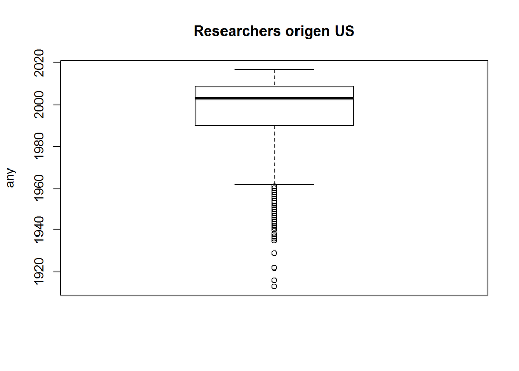

```r
#(veure si en US i en ES quin any hi ha més investigadors)
#Boxplot per US i un altre per ES. I un per total i altre només per PHD i cadascun per total o si migren
a1<-mydataResearcher$any[mydataResearcher$origen_country=="US"]
a2<-mydataResearcher$any[which(mydataResearcher$origen_country=="US")]
a3<-mydataResearcher$any[mydataResearcher$origen_country=="US"&!is.na(mydataResearcher$any)]
a4<-mydataResearcher$any[which(mydataResearcher$origen_country=="US" &!is.na(mydataResearcher$any))]

b1<-mydataResearcher$has_migrated[mydataResearcher$origen_country=="US"]

c1<-mydataResearcher$has_phd[mydataResearcher$origen_country=="US"]

d1<-mydataResearcher$any[mydataResearcher$origen_country=="US" & mydataResearcher$has_phd=="True"]

e1<-mydataResearcher$has_migrated[mydataResearcher$origen_country=="US"& mydataResearcher$has_phd=="True"]
#1.Boxplot per ORIGEN=US, mirar per any.
outUS<-boxplot(a1, main="Researchers origen US",ylab="any")$out
```

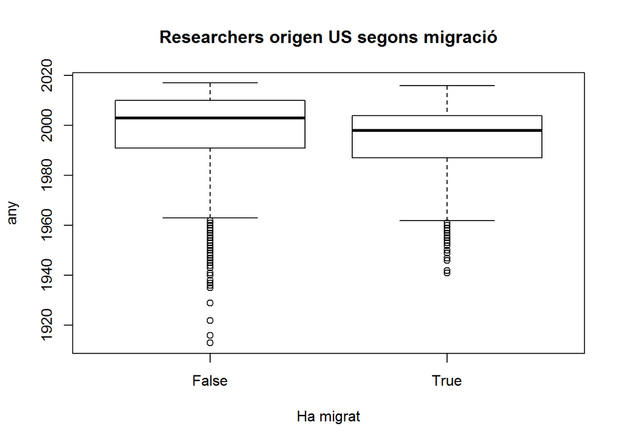

```r
#2.Boxplot per ORIGEN=US, mirar per any (en el mateix gràfic els migration TRUE i FALSE).
boxplot(a1~b1, main="Researchers origen US segons migració",ylab="any",xlab="Ha migrat")
```

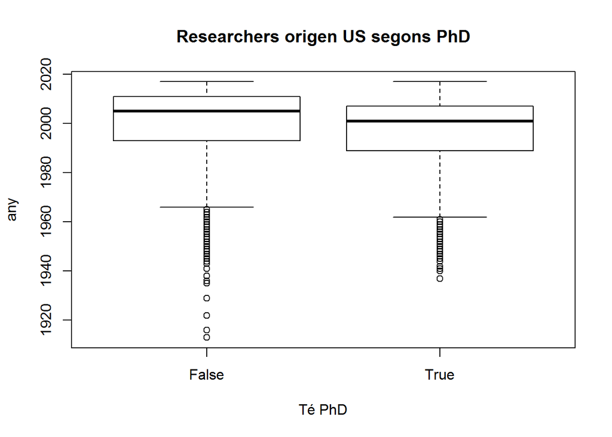

```r
#3.Boxplot per ORIGEN=US i que tenen PhD, mirar per any (en el mateix gràfic els migration TRUE i FALSE).
boxplot(a1~c1, main="Researchers origen US segons PhD",ylab="any",xlab="Té PhD")
```

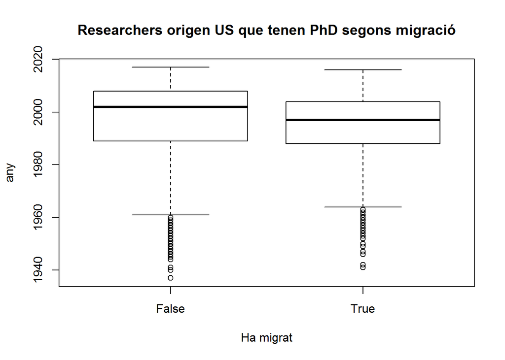

```r
#4.Boxplot per ORIGEN=US i que tenen PhD, mirar per any (en el mateix gràfic els migration TRUE i FALSE).
boxplot(d1~e1, main="Researchers origen US que tenen PhD segons migració",ylab="any",xlab="Ha migrat")
```

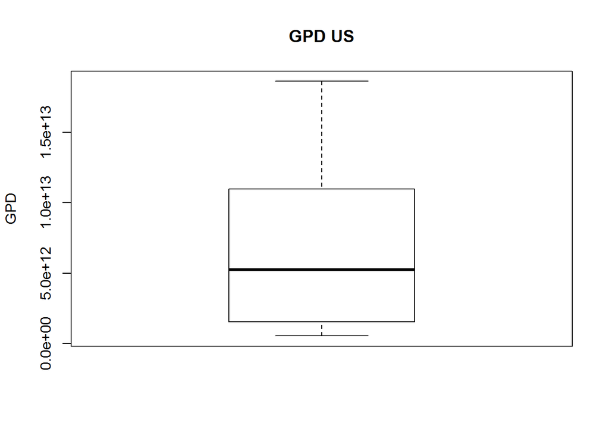

```r
#4.5.6. Anàleg per ORIGEN=ES


#Referent a renta per càpita:
f1<-mydataGDP$Value[(mydataGDP$ISO3166.1.Alpha.2=="US")]
#7.Boxplot per país=US
boxplot(f1, main="GPD US",ylab="GPD")
```

```r
#8.Boxplot per país=ES
```

Pel que fa a dades d’investigadors de EEUU, en tots els boxplot que hem visualitzat tenim outliers. En global, el nombre total d’outliers és 1107. Observem que hi ha outliers de dades corresponents a anys anteriors al 1960. Concretament l’interva d’anys outlier és [1913,1961] . Hem de tenir en compte que ORCID va sorgir al 2012. No sabem si són dades mal introduïdes o són correctes. Les mantindrem en el nostre estudi, ja que aporten informació, però en anàlisis posteriors podem tenir en compte que dades antigues no són tan completes com les que hi ha entorn l’any 2000.

Referent a la renda per càpita, no observem outliers.

**Revisem dades d’origen ES**

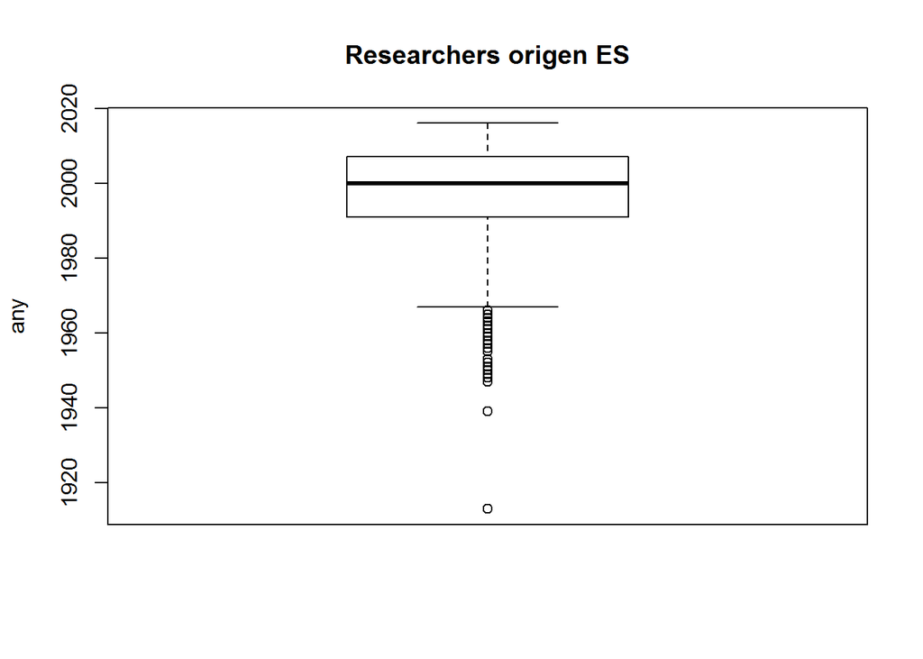

```r
#(veure si en ES i en ES quin any hi ha més investigadors)
#Boxplot per ES i un altre per ES. I un per total i altre només per PHD i cadascun per total o si migren
a1<-mydataResearcher$any[mydataResearcher$origen_country=="ES"]
a2<-mydataResearcher$any[which(mydataResearcher$origen_country=="ES")]
a3<-mydataResearcher$any[mydataResearcher$origen_country=="ES"&!is.na(mydataResearcher$any)]
a4<-mydataResearcher$any[which(mydataResearcher$origen_country=="ES" &!is.na(mydataResearcher$any))]

b1<-mydataResearcher$has_migrated[mydataResearcher$origen_country=="ES"]

c1<-mydataResearcher$has_phd[mydataResearcher$origen_country=="ES"]

d1<-mydataResearcher$any[mydataResearcher$origen_country=="ES" & mydataResearcher$has_phd=="True"]

e1<-mydataResearcher$has_migrated[mydataResearcher$origen_country=="ES"& mydataResearcher$has_phd=="True"]
#1.Boxplot per ORIGEN=ES, mirar per any.
outES<-boxplot(a1, main="Researchers origen ES",ylab="any")$out
```

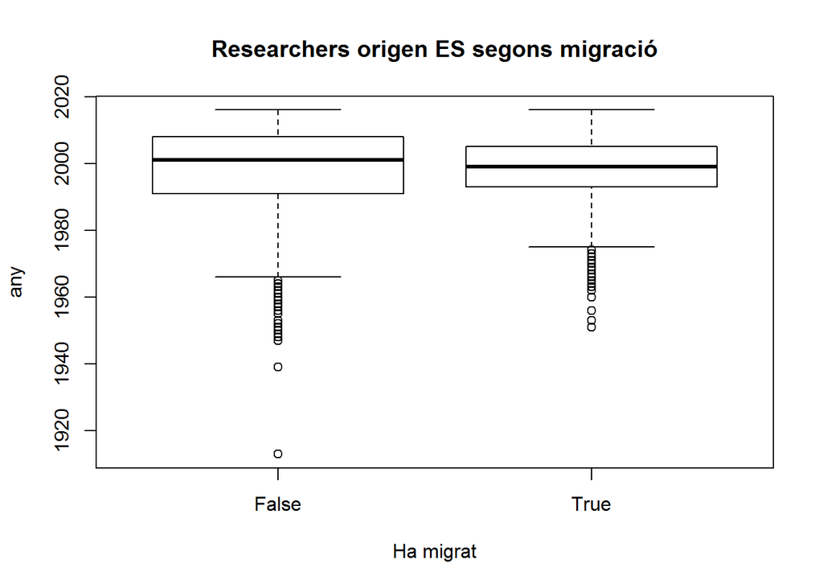

```r
#2.Boxplot per ORIGEN=ES, mirar per any (en el mateix gràfic els migration TRUE i FALSE).
boxplot(a1~b1, main="Researchers origen ES segons migració",ylab="any",xlab="Ha migrat")
```